# Mid-Term Data Analysis Project

Bret Wilde-Webster

04 November 2024

# TECHCORP Hiring Analysis

## 1. Introduction

Hiring is the first step in building any successful organization. Innovative, capable people, means an innovative and capable TECHCORP. Hiring is expensive and risky, the Tech Industry moves at break-neck pace, and competition for talent is fierce. To stay on top as a global tech firm, it is absolutely imperative that TECHCORPS hiring strategy constantly evolves.

The goal of this analysis is to improve and streamline hiring, making better quality candidates more accessible to the firm. This will be accomplished through a data set with 3500 applicants to positions at TECHCORP. The data includes personal information of candidates, their technical skill assessments, and the results of their interviewing. Ultimately, each candidate is filed as a “Yes” or “No” in a conclusion variable entitled “Hired.”

This data has been examined for six key factors that effect hiring decisions. The guiding question of this analysis is, “What affects hiring at TECHCORP?”

The examination is offered through the lens of specific metrics, including education pedigree and levels, technical aptitude, the digital footprint of candidates, and how well an individual interviewed. Each factor’s analysis is carefully documented, detailing the state of the data, the methods used, and our findings.

Afterwards, we will present our most key considerations from the analysis. This includes revisiting the findings deemed most important, additional insights only available once the initial findings are available, and new questions for future analysis. Finally, we will put forward our actionable recommendations based on those conclusions.

### 1.1 Preliminary Conclusions:

1. The combination of Technical Test Scores, Interview Scores, and Graduating From an Elite College have an overwhelmingly positive correlation with hiring outcomes.
2. There are some severe inefficiencies in the hiring process, with several variables having little to no effect on hiring outcomes at TECHCORP.
3. There appears to be elements of bias in the hiring outcomes with applicants who graduated from an elite university.

## 2. Data and Exploratory Analysis

This section will cover the data and exploratory analysis of the previously mentioned factors, six in total, using the hiring dataset. Hiring is extremely competitive at this firm, out of 3500 applicants, 246 were hired, or, a little less than 7%. This is important context, as key parts of this analysis only look at the split of those hired and those not hired.

### 2.1 Technical Skill Scores

Is there a relationship between technical skill scores and hiring outcomes?

**Data**

The issue with trying to evaluate the likelihood of being hired using an average for technical skills is that preferred qualifications differ drastically across job titles. What may be requested of an individual in data science may not be required of someone in a software engineering role.

The data provided does not have criteria for specific job titles, and each applicant is scored for each skill, e.g, all System Administrator applicants have a Python score, all Data Scientist applicants have a Java score, and so on. There are a total of 8 skill_score columns, each on a scale of 1 - 10.

**Method**

Due to the variety of factors at play in these skill scores, aggregation was needed to gain a holistic view of the effect of Technical Scores on Hiring. A new column was created entitled average_skill_scores, which computed an average skill score for each candidate across all eight skills. This new column was used to compare the average skill scores of hired applicants, and applicants not hired, formatted as table 2.1.1 Finally, a histogram was generated to show the distribution of average_skill_score across hiring outcomes, as seen in figure 2.1.1.

**Analysis**

**Results**

### 2.2 Technical Test Scores

Do Technical Test Scores play a role in determining hiring outcomes?

**Data**

Every applicant takes a technical test at some point in their hiring process at TECHCORP. They are scored on a scale from 1 - 10, similar to the technical skill scores.

**Method**

To assess the impact of test scores on hiring, an initial frequency table was computed, showing technical test scores of hired applicants. An additional table was generated which showed these numbers as proportions. Finally, a box plot was rendered to visualize this. Please refer to figure 2.2.1, table 2.2.1, and table 2.2.2.

**Analysis**

Figure 2.2.1 shows individuals hired and not hired, on a scale of technical test scores. With very few exceptions, almost all hired applicants scored at least an 8 or higher on the technical test. There are some outliers, however, a total of 13 exceptions. Fewer than 1% of all applicants who received less than an 8 on the technical test were hired.

**Results**

Based on these findings, there is sufficient evidence to determine a positive relationship between technical test scores and hiring outcomes. It can be safely assumed that if an applicant does not score at least an 8 on their technical test, then they are unlikely to be hired.

### 2.3 Interview Scores

What role do interview scores play in determining hiring outcomes?

**Data**

Every applicant is assigned an interview score based on their perfomance in their interviews during the hiring process at TECHCORP. They are scored on a scale from 1 - 10, similar to the technical test scores.

**Method**

To assess the impact of test scores on hiring, an initial frequency table was computed, showing interview scores of hired applicants. An additional table was generated which showed these numbers as proportions. Finally, a box plot was rendered to visualize this. Please refer to figure 2.3.1, table 2.3.1, and table 2.3.2.

**Analysis**

Given the similarity to the assessment scale of technical test score, a similar analysis was completed. Figure 2.3.1 shows individuals hired and not hired, on a scale of interview scores. With very few exceptions, almost all hired applicants had an interview score of at least 8 or greater. There are some outliers, however, a total of 12 exceptions. Fewer than 1% of all applicants who received less than an 8 on their interview were hired.

**Results**

Based on these findings, there is sufficient evidence to determine a positive relationship between interview scores and hiring outcomes. It can be safely assumed that if an applicant does not score at least an 8 on their interview, then they are unlikely to be hired.

### 2.4 Digital Footprint

Does having a digital footprint, such as on professional media sites like Linkedin and Github, have an effect on hiring outcomes?

**Data**

Four categories were used in answering this question. Two of which were categorical and filed as a “Yes” or “No,” git_hub_profile and linked_in_profile. The other two were numeric, one, git_hub_projects, showing the number of projects each applicant with a Git Hub profile had, and one named linked_in_connections, which showed how many connections an applicant with a Linkedin profile had.

**Method**

Two of the frequency tables, 2.4.1 and 2.4.2, show the total number of applicants who have either a Git Hub profile or a Linkedin Profile, expressed as a percentage. Two more frequency tables, 2.4.3 and 2.4.4, show the proportions of hired and not hired applicants who have either a Git Hub profile or a Linkedin Profile. Moving to the grouped summary table, 2.4.5, this table shows average Linkedin Connections and average Git Hub Projects, by those hired and those not hired.

**Analysis**

Through tables 2.4.1 through 2.4.4, It can be observed that the proportions of the population of total applicants and hired applicants, with either type of profile, are nearly identical. While there are a high number of hired applicants with either type of profile, this can largely be attributed to the large proportion of total applicants with profiles.

That is to say that, of all applicants, 29.8% had a Linkedin Profile, and of all *hired* applicants, 31.7% had a Linkedin Profile.The same goes for Git Hub Profiles. Of all applicants, 40.4% had a Git Hub Profile, and of all hired applicants, 39.4% had a Git Hub Profile.

Table 2.4.5 evaluates the average number of Git Hub projects and Linkedin Connections among the population of individuals with profiles. These, as well, are nearly identical.

**Results**

If there were to be any emphasis in hiring on those who have either type of profile or who have more or less projects/connections, one might expect to see a difference in statistics between the hired and not hired populations. As there are no meaningful observable differences it can be concluded that having a professional digital footprint has no effect on hiring outcomes.

### 2.5 Education Levels

Does education level play a role in determining hiring outcomes?

**Data**

The data selected to answer this question are the categorical variables, hired, position_applied_for, and education_level. The positions available for application are Data Scientist, Web Developer, Software Engineer, System Analyst, and Database Administrator. The listed education levels, which record the *highest* education level achieved, are high school, bachelors, masters, and PhD.

**Method**

In order to create figure 2.5.1, a table was formatted computing proportional share of hired applicant’s education levels by position applied for. Different fields require different levels of preparation for the responsibilities entailed by a specific role. The core responsibilities and competencies of a System Analyst, and those of a Data Scientist, are vastly different.

An initial frequency table of education levels was created to explore the data, table 2.5.1. A second frequency table, 2.5.2, was created to explore the shares of education levels between hired applicants. A third frequency table, table 2.5.3, expressed the proportion of education levels in hired applicants across position applied Finally, figure 2.5.1 was created to visualize the share each education level had in each position, showing only hired applicants.

**Analysis**

table 2.5.1, which shows nearly uniform distribution of education levels across all applicants. The education levels of the applicant population was uniformly distributed, but the distribution among those hired was not. Table 2.5.2 shows each education level holds a similarly sized share of hired applicants, with some small differences. The largest difference being a 7% gap between hired applicants holding a bachelors and hired applicants holding a PhD.

Drilling down deeper, the differences in education level grow much wider when introducing the positions applied for. Table 2.5.3 is quite different from the rest, showing large differences in the distribution of education levels held by hired applicants across positions applied for. For example, there were 14% more hired applicants in Data Science holding PhD’s than hired applicants holding PhDs working in Database Administration. Hiring in Software Engineer positions seem dominated by applicants holding a bachelor’s degree, sitting at 33% of total hired Software Engineers.

**Results**

Referring to figure 2.5.1., these findings are made much more obvious. Each department has been plotted, showing the different proportions of education levels. As mentioned, some categories seem to favor specific degrees more than others. This does not hold true within departments, as there are more high school educated Data Scientists than there are PhD educated Data Scientists.

However, these findings do have weight when looking *across* departments. The 14% difference between those in Data Science holding PhD’s and those holding PhD’s working in Database Administration, would imply that a candidate with a PhD would be more successful in applying to one department over the other. The same can be said for several other departments, such as Bachelor educated individuals being preferred in Software Engineering.

At a high level, education level is not a heavily weighed factor when deciding who to hire and who not to hire at this firm. There does, however, appear to be some relationship between education level and positions applied for.

### 2.6 Graduating From an Elite College

Does graduating from an elite college have a meaningful effect on hiring outcomes?

**Data**

As the analysis drilled deeper, many variables were used. The main categorical variable in use was, of course, graduated_from_elite_college, as a “Yes” or “No.” That variable was examined on the population of all applicants and on the population of only those applicants hired. Further analysis used the preferred_work_environment variable, which included remote, in office, hybrid, and flexible. Final analysis took place using the technical test scores variable and the interview score variable.

**Method**

Table 2.6.1 was created to get a grasp on how many applicants were from an elite college. Table 2.6.2 was created to find how many hired applicants were from an elite college. Table 2.6.3 shows the proportion of hired applicants in different work settings, organized by whether or not they have graduated from an elite university. From previous analysis, it was noted that some applicants who did not score at least an 8 on either the interview or the technical test, were still hired. To find these outliers, two summary tables were made, 2.6.4 and 2.6.5., filtered for hired applicants with either a technical or interview score less than 8.

**Analysis**

Of the population of those who graduated from an elite college, 7.7% were hired. Of those who did not graduate from an elite college, 6.8% were hired. This seems innocuous on the surface, but the pool of competition among elite college graduates is smaller while the rate of success is slightly higher than of applicants not from an elite institution.

From table 2.6.1 it was found that 27% of all applicants are from an elite college. From table 2.6.2 it was found that a staggering 30% of all hires were from an elite college. Table 2.6.3 shows that 48% of all in office hires are from an elite college, almost half of all in office workers. Tables 2.6.4 and 2.6.5 show that of those 12 to 13 individuals with either a test or interview score less than 8, all of them were from an elite college. They were all marked as strong cultural fits, and all preferred to work in office.

**Results**

These findings would seem to indicate a strong bias towards applicants who are graduated from an elite college. From this analysis, there is more than enough evidence to conclude that graduating from an elite college has a significant and postive impact on hiring outcomes.

## 3. Conclusion(s)/Discussion.

### 3.1 Revisiting Key Questions, Synthesis of Findings.

Based on the analysis of the six factors listed in this report, several discoveries were made. Of the criteria listed in this report, technical skill scores and professional media such as Linkedin and Git Hub had the least impact on hiring decisions. Whether an applicant did or did not have a Linkedin or Github made no difference in whether or not they were hired. Similarly, technical skill scores do not seem to have a relationship with hiring, positively or negatively.

Education levels have negligible impact on hiring success, broadly, but when examined by role, there seems to be a preference within positions for candidates with specific education levels.

The largest factors in determining whether or not an applicant will be hired, are their test and interview scores, and whether or not the applicant graduated from an elite college.

### 3.3 Future Analysis

Technical skill scores should be able to be connected with individual job roles, but that analysis is impossible without criteria for each position being included in the dataset. The same rule applies to education levels by position applied for. Higher quality analysis could be performed in qualification preferences were baked in to the data provided, this would allow further analysis on the quality and kind of candidates TECHCORP is looking for.

Education levels are missing an Associates degree, which some roles may be looking for, as an in-between for high school education and Bachelor’s degrees.

Further analysis might include, difference in interview dates and decision dates effect on hiring, years of experience effect on hiring, and workplace preference’s effect on hiring.

### 3.4 Final Recommendations

It might be wise to streamline hiring through modes which are already emphasized. Eliminate Git Hub and Linkedin as a criteria, along with all skill score evaluations. The technical test likely already assesses technical aptitude, and is already likely tuned to the positions core competencies. Additionally, with the emphasis on interviewing, candidate fit can be well assessed through interpersonal evaluations. In this case, skill scores and digital footprint may very well be bloat, obscuring real insights from TECHCORPS hiring process that could be valuable to business leaders.

There appears to be significant bias surrounding applicants graduating from an elite college. Reassess hiring training and ensure that the hiring team making the decisions for outcomes are not over represented by any one group, such as elite graduates, which may inadvertently skew decision making.

## 4. Appendix/Appendices.

Here is all the code from which I drew my conclusions, and generated my report.

### 1. Technical Skill Scores

Table 2.1.1 the average skill score of a hired candidate and a candidate not hired

| Hired | Average Skill Score |
| --- | --- |
| No | 5.51 |
| Yes | 5.58 |

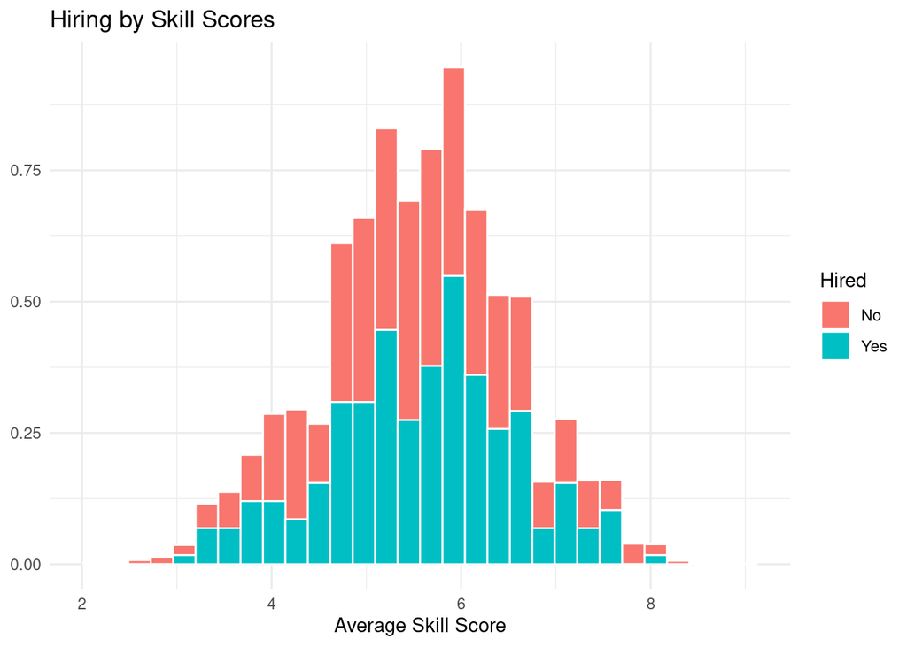

Figure 2.1.1: Histogram of Technical Skill Scores

```r
# make a new column with average skill scores for each applicant, to be able to aggregate them for use in hiring.
CandidateTechnicalScores <- CandidateTechnicalScores |>
  group_by(candidate_id) |>
  mutate(average_skill_score = round(mean
            (c_across(c("python_skill_score",
                         "java_skill_score",
                         "sql_skill_score",
                         "r_skill_score",
                         "machine_learning_skill_score",
                         "html_skill_score",
                         "css_skill_score",
                         "java_script_skill_score"))), 2))


# Push new column to joined table
Candidate_Skills_Interviews_and_data <-
 Candidate_Skills_Interviews_and_data |>
  left_join(CandidateTechnicalScores |>
              select(candidate_id, average_skill_score),
            by = "candidate_id")


# Take a look at the distributions of average skill scores across those hired
# Show the difference in average skill scores between hiring outcomes
average_skill_scores <- Candidate_Skills_Interviews_and_data |>
  group_by(hired) |>
  summarise(average_skill_score = round(mean(c_across(c
      (python_skill_score,
        java_skill_score,
        sql_skill_score,
        r_skill_score,
        machine_learning_skill_score,
        html_skill_score,
        css_skill_score,
        java_script_skill_score))), 2))


# Stacked histogram to show the lack of difference in technical scores between those hired and those not hired.
Figure_2.1.1 <-Candidate_Skills_Interviews_and_data |>
  ggplot(aes(x = average_skill_score, fill = hired)) +
  geom_histogram(aes(y = ..density..),  color = 'white') +
  labs(title = "Hiring by Skill Scores",
       x = "Average Skill Score",
       y = NULL,
       fill = "Hired") +
  theme_minimal() +
  theme(legend.position = "right")
```

### 2. Do Technical Test Scores Matter?

Table 2.2.1: Frequency Table of Applicants Technical Test Scores by Hired

|  | hired |  |
| --- | --- | --- |
| technical_test_score | No | Yes |
| 1 | 344 | 0 |
| 2 | 356 | 1 |
| 3 | 355 | 2 |
| 4 | 334 | 2 |
| 5 | 360 | 5 |
| 6 | 362 | 2 |
| 7 | 321 | 1 |
| 8 | 299 | 71 |
| 9 | 280 | 93 |
| 10 | 243 | 69 |

Table 2.2.2: Frequency Table of Hired Applicants Technical Test Scores

| technical_test_score | n | percent |
| --- | --- | --- |
| 2 | 1 | 0.4% |
| 3 | 2 | 0.8% |
| 4 | 2 | 0.8% |
| 5 | 5 | 2.0% |
| 6 | 2 | 0.8% |
| 7 | 1 | 0.4% |
| 8 | 71 | 28.9% |
| 9 | 93 | 37.8% |
| 10 | 69 | 28.0% |

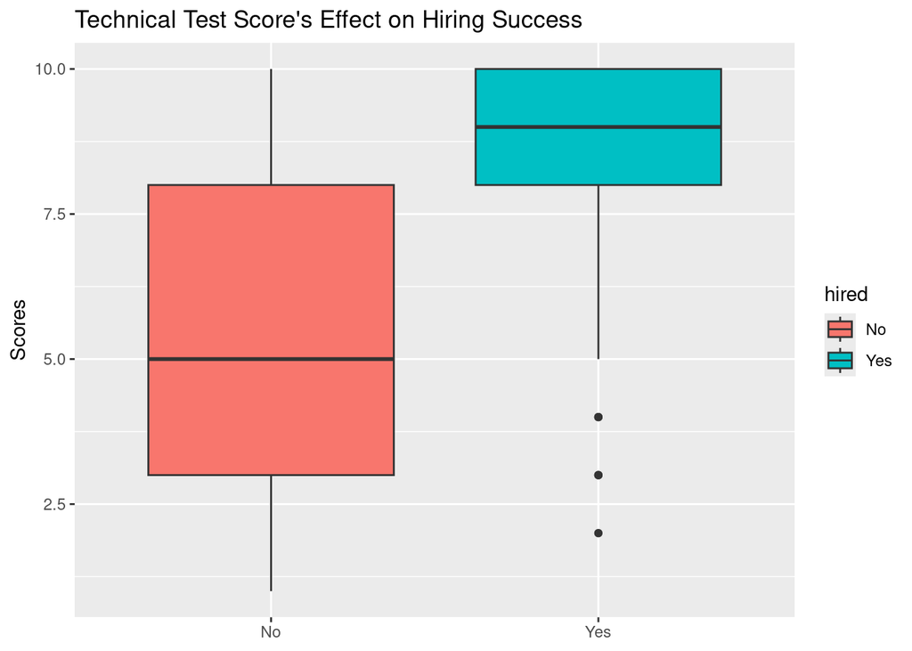

Figure 2.2.1: Boxplot of Technical Test Scores

```r
Table_2.2.1 <- Candidate_Skills_Interviews_and_data |>
  tabyl(technical_test_score, hired) |>
  adorn_title(placement = "top") # Seeing distributions of technical test scores across hiring.

Table_2.2.2 <- Hired_applicants |>
  tabyl(technical_test_score) |>
  adorn_pct_formatting() # Drilling a little deeper on technical testing

Figure_2.2.1 <- Candidate_Skills_Interviews_and_data |>
ggplot(aes(x = hired, y = technical_test_score, fill = hired)) +
  geom_boxplot() +
  labs(
    title = "Technical Test Score's Effect on Hiring Success",
    x = NULL,
    y = "Scores"
  )
```

### 3. Do Interview Scores Matter in Hiring Outcomes?

Table 2.3.1: Frequency Table of Applicants Interview Scores by Hired

|  | hired |  |
| --- | --- | --- |
| interview_score | No | Yes |
| 1 | 347 | 5 |
| 2 | 326 | 0 |
| 3 | 348 | 1 |
| 4 | 351 | 1 |
| 5 | 372 | 3 |
| 6 | 304 | 2 |
| 7 | 326 | 0 |
| 8 | 294 | 75 |
| 9 | 311 | 75 |
| 10 | 275 | 84 |

Table 2.3.2: Frequency Table of Hired Applicants Interview Scores

| interview_score | n | percent |
| --- | --- | --- |
| 1 | 5 | 2.0% |
| 3 | 1 | 0.4% |
| 4 | 1 | 0.4% |
| 5 | 3 | 1.2% |
| 6 | 2 | 0.8% |
| 8 | 75 | 30.5% |
| 9 | 75 | 30.5% |
| 10 | 84 | 34.1% |

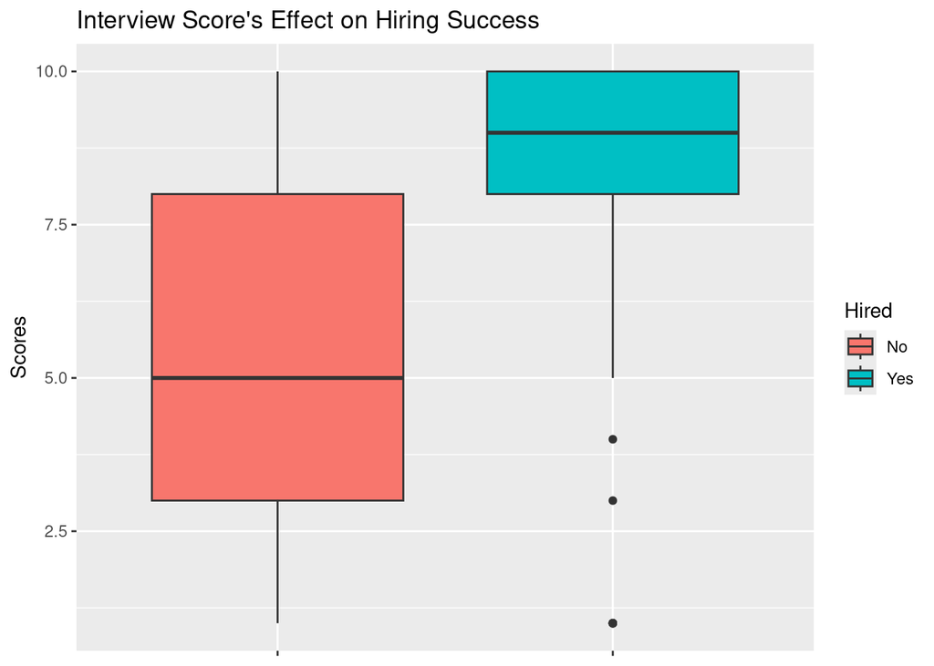

Figure 2.3.1: Boxplot of Interview Scores

```r
Table_2.3.1 <- Candidate_Skills_Interviews_and_data |>
  tabyl(interview_score, hired) |>
  adorn_title(placement = "top") # seeing distributions of interview scores across hiring. They look similar to the technical test scores distributions across hiring.

Table_2.3.2 <- Hired_applicants |>
  tabyl(interview_score) |>
  adorn_pct_formatting() # Confirming my suspicions, almost all hired candidates had at least on 8 on the interview score, just like the technical test.


Figure_2.3.1 <- Candidate_Skills_Interviews_and_data |>
ggplot(aes(x = hired, y = interview_score, fill = hired)) +
  geom_boxplot() +
  labs(
    title = "Interview Score's Effect on Hiring Success",
    x = NULL,
    y = "Scores",
    fill = "Hired") +
  theme(axis.text.x = element_blank()) # Box plot showing distribution, and outliers.
```

### 4. Does having a digital footprint, such as Linkedin and Github, make a difference in hiring outcomes?

```r
Table_2.4.1 <- Candidate_Skills_Interviews_and_data |>
  tabyl(linked_in_profile) |>
  adorn_pct_formatting()# show the total number of applicants with a Linkedin profile

Table_2.4.2 <- Candidate_Skills_Interviews_and_data |>
  tabyl(git_hub_profile) |>
  adorn_pct_formatting() # show the total number of applicants with a Git Hub profile

Table_2.4.3 <- Candidate_Skills_Interviews_and_data |>
  tabyl(hired, git_hub_profile) |>
  adorn_percentages() |>
  adorn_pct_formatting() |>
  adorn_title(placement = "top") # show what percentage of hired individuals have a Git Hub profile against those who were not hired

Table_2.4.4 <- Candidate_Skills_Interviews_and_data |>
  tabyl(hired, linked_in_profile) |>
  adorn_percentages() |>
  adorn_pct_formatting() |>
  adorn_title(placement = "top") # show what percentage of hired individuals have a Linkedin profile against those who were not hired


Table_2.4.5 <- Candidate_Skills_Interviews_and_data |>
  group_by(hired) |>
  summarize(average_projects = round(mean(git_hub_projects), 2),
            average_connections = round(mean(linked_in_connections), 2))
```

Table 2.4.1: Frequency Table of Applicants with a Linkedin Profile

| linked_in_profile | n | percent |
| --- | --- | --- |
| No | 2456 | 70.2% |
| Yes | 1044 | 29.8% |

Table 2.4.2: Frequency Table of Applicants with a Git Hub Profile

| git_hub_profile | n | percent |
| --- | --- | --- |
| No | 2085 | 59.6% |
| Yes | 1415 | 40.4% |

Table 2.4.3: Frequency table of Individuals With a Git Hub profile by Hired

|  | git_hub_profile |  |
| --- | --- | --- |
| hired | No | Yes |
| No | 59.5% | 40.5% |
| Yes | 60.6% | 39.4% |

Table 2.4.4: Frequency table of Individuals With a Linkedin profile by Hired

|  | linked_in_profile |  |
| --- | --- | --- |
| hired | No | Yes |
| No | 70.3% | 29.7% |
| Yes | 68.3% | 31.7% |

Table 2.4.5: Summary table of Average Connections and Projects by Hired

| hired | average_projects | average_connections |
| --- | --- | --- |
| No | 10.32 | 145.87 |
| Yes | 10.20 | 141.56 |

### 5. Does Education Level Affect Hiring?

```r
freq_table_2.5.1 <- Candidate_Skills_Interviews_and_data |>
  tabyl(education_level) # Education levels are evenly distributed, each taking up about 25% of all applicants.


# Frequency table of education levels in hired applicants
freq_table_2.5.2 <- Hired_applicants |>
  tabyl(education_level)

# Showing percentage of education level across position applied for, split by whether or not they were hired
freq_table_2.5.3 <- Hired_applicants |>
  tabyl(position_applied_for, education_level) |>
  adorn_percentages() |>
  adorn_pct_formatting()
```

Table 2.5.1: Frequency table of all applicants education levels

| education_level | n | percent |
| --- | --- | --- |
| Bachelor’s | 895 | 0.2557143 |
| High School | 845 | 0.2414286 |
| Master’s | 881 | 0.2517143 |
| PhD | 879 | 0.2511429 |

Table 2.5.2: Frequency Table of Education Levels in Hired Applicants

| education_level | n | percent |
| --- | --- | --- |
| Bachelor’s | 69 | 0.2804878 |
| High School | 61 | 0.2479675 |
| Master’s | 63 | 0.2560976 |
| PhD | 53 | 0.2154472 |

Table 2.5.3: Proportions of Education Level in Hired Applicants Across Position Applied For

| position_applied_for | Bachelor’s | High School | Master’s | PhD |
| --- | --- | --- | --- | --- |
| Data Scientist | 18.4% | 30.6% | 22.4% | 28.6% |
| Database Administrator | 31.4% | 25.7% | 28.6% | 14.3% |
| Software Engineer | 33.3% | 22.8% | 26.3% | 17.5% |
| System Analyst | 28.1% | 24.6% | 24.6% | 22.8% |
| Web Developer | 29.2% | 20.8% | 27.1% | 22.9% |

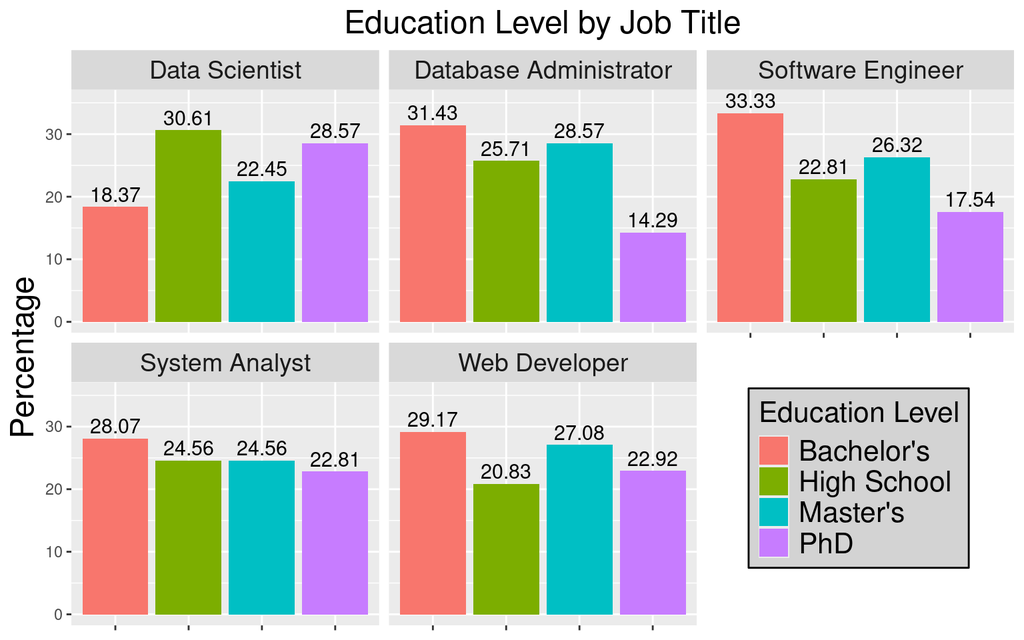

Figure 2.5.1: Distribution of Education by Position

```r
# There are very different hiring numbers for each department. I should reformat these as proportions if I want to isolate education level.


Education_proportions <- Hired_applicants  |>
  group_by(position_applied_for, education_level) |>
  summarize(count = n()) |>
  mutate(percentage = count / sum(count) * 100)

Education_proportions <-  Education_proportions |>
 mutate(percentage = round(percentage, 2))


########################################################################################

Figure_2.5.1 <- ##  Chart showing education levels in job titles as a percentage
  Education_proportions |>
ggplot(aes(x = education_level, y = percentage, fill = education_level)) +
  geom_col() +
  facet_wrap(~position_applied_for) +
  geom_text(aes(label = percentage), nudge_y = 2, size = 4) +
  labs(title = "Education Level by Job Title", x = NULL, y = "Percentage", fill = "Education Level") +
  theme(
    plot.title = element_text(hjust = 0.5, size = 18),
    axis.title.y = element_text(size = 18),
    axis.text.x = element_blank(),
    strip.text = element_text(size = 14),
    legend.position = c(0.835,0.275),
    legend.text = element_text(size = 16),
    legend.title = element_text(size = 16),
    legend.background = element_rect(fill="lightgrey",
                                  colour ="black"))
```

### 6. Graduating from an elite College

```r
Table_2.6.1 <- Candidate_Skills_Interviews_and_data |>
  tabyl(graduated_from_elite_college)  # Just to get an idea of how many applicants were ECG. 27% of applicants are ECG


Table_2.6.2 <- Hired_applicants |> # 30% of all hires are ECG!
  tabyl(graduated_from_elite_college) |>
  adorn_pct_formatting()


## Proportion of Hired Applicants in different Work Settings, organized by whether or not they have graduated from an elite university.
Table_2.6.3 <- Hired_applicants|>
  tabyl(preferred_work_environment, graduated_from_elite_college) |>
  adorn_percentages() |>
  adorn_pct_formatting() |>
  adorn_title(placement = "top") # staggering number of in office hires are from an elite university, almost half!



## Looking for the technical test score outliers
Table_2.6.4 <- Candidate_Skills_Interviews_and_data |>
  group_by(candidate_id) |>
  filter(hired == "Yes",
         technical_test_score < 8) |>
  select(candidate_id, hired, technical_test_score, graduated_from_elite_college, cultural_fit, preferred_work_environment)
# All elite, all marked as strong cultural fits, and all preferred to work in office. There's definitely a trend here.


## Looking for the interview score outliers
Table_2.6.5 <-Candidate_Skills_Interviews_and_data |>
  group_by(candidate_id) |>
  filter(hired == "Yes",
         interview_score < 8) |>
  select(candidate_id, hired, technical_test_score, graduated_from_elite_college, cultural_fit, preferred_work_environment) # All ECG, all marked as strong cultural fits, and all preferred to work in office. There's definitely a trend here.
```

Table 2.6.1: Frequency Table of all Elite Graduate Candidates

| graduated_from_elite_college | n | percent |
| --- | --- | --- |
| No | 2524 | 0.7211429 |
| Yes | 976 | 0.2788571 |

Table 2.6.2: Frequency Table of all Hired Elite Graduate Candidates

| graduated_from_elite_college | n | percent |
| --- | --- | --- |
| No | 171 | 69.5% |
| Yes | 75 | 30.5% |

Table 2.6.3: Frequency table of Hired Elite Graduates in Preferred Work Environment

|  | graduated_from_elite_college |  |
| --- | --- | --- |
| preferred_work_environment | No | Yes |
| Field Work | 74.5% | 25.5% |
| Flexible | 79.1% | 20.9% |
| Fully Remote | 74.5% | 25.5% |
| Hybrid | 76.3% | 23.7% |
| In-Office | 52.2% | 47.8% |

Table 2.6.4: Summary Table of Technical Test Outliers

| candidate_id | hired | technical_test_score | graduated_from_elite_college | cultural_fit | preferred_work_environment |
| --- | --- | --- | --- | --- | --- |
| 189 | Yes | 7 | Yes | Strong Fit | In-Office |
| 506 | Yes | 5 | Yes | Strong Fit | In-Office |
| 602 | Yes | 4 | Yes | Strong Fit | In-Office |
| 880 | Yes | 3 | Yes | Strong Fit | In-Office |
| 1118 | Yes | 5 | Yes | Strong Fit | In-Office |
| 1348 | Yes | 3 | Yes | Strong Fit | In-Office |
| 1375 | Yes | 5 | Yes | Strong Fit | In-Office |
| 2159 | Yes | 4 | Yes | Strong Fit | In-Office |
| 2458 | Yes | 6 | Yes | Strong Fit | In-Office |
| 2920 | Yes | 5 | Yes | Strong Fit | In-Office |
| 3114 | Yes | 6 | Yes | Strong Fit | In-Office |
| 3382 | Yes | 5 | Yes | Strong Fit | In-Office |
| 3443 | Yes | 2 | Yes | Strong Fit | In-Office |

Table 2.6.5: Summary Table of Interview Outliers

| candidate_id | hired | technical_test_score | graduated_from_elite_college | cultural_fit | preferred_work_environment |
| --- | --- | --- | --- | --- | --- |
| 602 | Yes | 4 | Yes | Strong Fit | In-Office |
| 880 | Yes | 3 | Yes | Strong Fit | In-Office |
| 1348 | Yes | 3 | Yes | Strong Fit | In-Office |
| 1369 | Yes | 10 | Yes | Strong Fit | In-Office |
| 1375 | Yes | 5 | Yes | Strong Fit | In-Office |
| 2007 | Yes | 10 | Yes | Strong Fit | In-Office |
| 2159 | Yes | 4 | Yes | Strong Fit | In-Office |
| 2278 | Yes | 9 | Yes | Strong Fit | In-Office |
| 2458 | Yes | 6 | Yes | Strong Fit | In-Office |
| 2920 | Yes | 5 | Yes | Strong Fit | In-Office |
| 3114 | Yes | 6 | Yes | Strong Fit | In-Office |
| 3443 | Yes | 2 | Yes | Strong Fit | In-Office |

### 7. Conclusion Plot

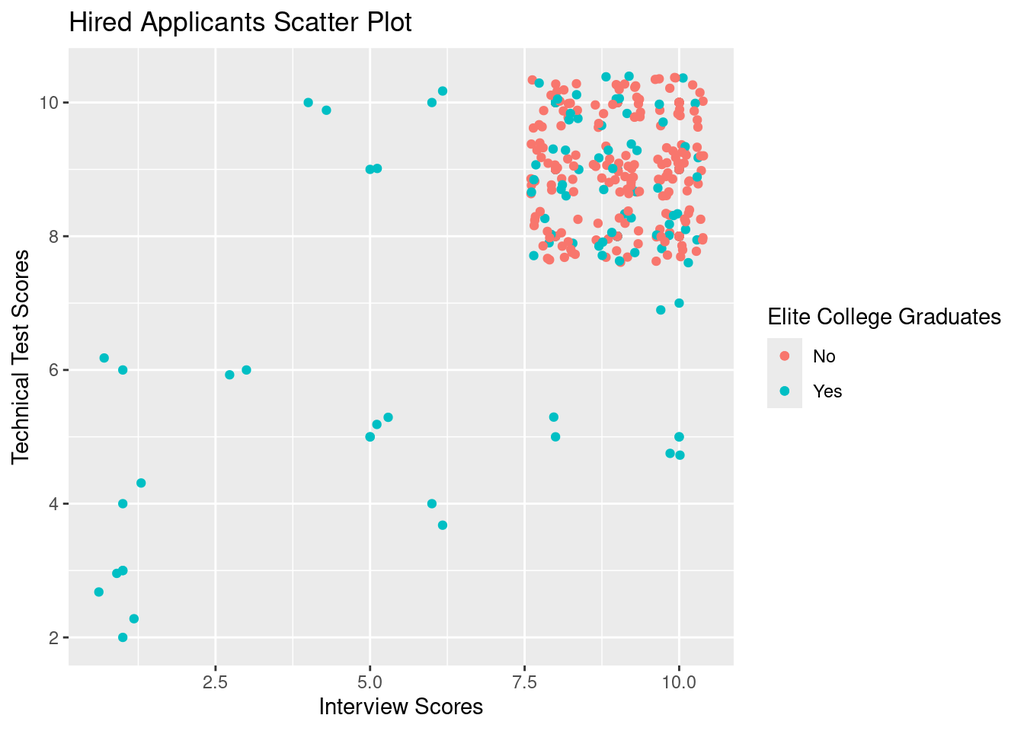

Figure 3.1.1: Scatter Plot of Hired Applicant Interview and Technical Scores, Showing Elite Graduates

```r
Figure_3.1.1 <- Hired_applicants |>
  ggplot(aes(x = interview_score, y = technical_test_score, color = graduated_from_elite_college)) +
  geom_point() +
  geom_jitter() +
  labs(title = "Hired Applicants Scatter Plot",
       x = "Interview Scores",
       y = "Technical Test Scores",
       color = "Elite College Graduates")
```